# Lab 4: Coffee Lovers Unite

Author

Samuel Lonac

# Lab 4: Coffee Lovers Unite

```python
!pip install bs4
```

```python
import pandas as pd
import requests
from bs4 import BeautifulSoup
import re
```

# Scrape Location Counts

#### 1. Using the beautifulsoup library to scrape the data from menuism.com on state names and corresponding number of store locations for coffee chains.

```python
#response = requests.get("https://www.menuism.com/restaurant-locations/starbucks-coffee-39564")
#soup = BeautifulSoup(response.content, "html.parser")
```

```python
"""
def pull_state_and_number(url, chain_name):
    rows = []
    response = requests.get(url)
    soup = BeautifulSoup(response.content, "html.parser")

    #looking for a tags where class is empty
    results = soup.find_all("a", attrs={"class" : ""})

    #specifying pattern to look for state locations
    state_pattern = fr"(.*)(?=\s+{chain_name} locations)"

    #specifying pattern to look for number of locations
    number_pattern= fr"(?<={chain_name} locations \()(\d+)"

    for result in results:
        #searching the state pattern in the text of each result
        state_match = re.search(state_pattern, result.text)

        #searching the number pattern in the text of each result
        number_match = re.search(number_pattern, result.text)

        #excluding blank values from table
        if (state_match != None) & (number_match != None):
            state = state_match.group(0)
            number = int(number_match.group(1))

            rows.append({
            "State": state,
            "Count" : number,
            "Store" : chain_name
            })

        else:
            None

    return rows
"""
```

[output not shown]

```python
"""

#creating Starbucks DataFrame

starbucks = pull_state_and_number("https://www.menuism.com/restaurant-locations/starbucks-coffee-39564", "Starbucks")

starbucks_df = pd.DataFrame(starbucks)

#creating Dunkin DataFrame

dunkin = pull_state_and_number("https://www.menuism.com/restaurant-locations/dunkin-donuts-181624", "Dunkin’ Donuts")

dunkin_df = pd.DataFrame(dunkin)

#creating Peets DataFrame

peets = pull_state_and_number("https://www.menuism.com/restaurant-locations/peets-coffee-tea-84051", "Peet’s Coffee & Tea")

peets_df = pd.DataFrame(peets)

#creating Tim Horton DataFrame

tim = pull_state_and_number("https://www.menuism.com/restaurant-locations/tim-hortons-190025", "Tim Horton’s")

tim_df = pd.DataFrame(tim)

#creating Panera DataFrame

panera = pull_state_and_number("https://www.menuism.com/restaurant-locations/panera-bread-4258", "Panera Bread")

panera_df = pd.DataFrame(panera)

#creating Caribou DataFrame

caribou = pull_state_and_number("https://www.menuism.com/restaurant-locations/caribou-coffee-164861", "Caribou Coffee")

caribou_df = pd.DataFrame(caribou)

#creating Au Bon Pain DataFrame

aubon = pull_state_and_number("https://www.menuism.com/restaurant-locations/au-bon-pain-69342", "Au Bon Pain")

aubon_df = pd.DataFrame(aubon)

#creating Coffee Bean and Tea Leaf DataFrame

coffee_bean = pull_state_and_number("https://www.menuism.com/restaurant-locations/the-coffee-bean-tea-leaf-165988", "The Coffee Bean & Tea Leaf")

coffee_bean_df = pd.DataFrame(coffee_bean)

#creating McDonalds DataFrame

mcdonalds = pull_state_and_number("https://www.menuism.com/restaurant-locations/mcdonalds-21019", "McDonald’s")

mcdonalds_df = pd.DataFrame(mcdonalds)

"""
```

[output not shown]

## 2. Writing stateabb() function

```python
def stateabb(state_name):
    """
    Convert the given state name to its abbreviation.

    Parameters:
    - state_name (str): The name of the state.

    Returns:
    - str: The abbreviation of the state if found, otherwise None.

    Example:
    >>> stateabb("California")
    'CA'
    """
    #creating state abbreviation dictionary

    state_abbreviations = {
        'Alabama': 'AL',
        'Alaska': 'AK',
        'Arizona': 'AZ',
        'Arkansas': 'AR',
        'California': 'CA',
        'Colorado': 'CO',
        'Connecticut': 'CT',
        'Delaware': 'DE',
        'Florida': 'FL',
        'Georgia': 'GA',
        'Hawaii': 'HI',
        'Idaho': 'ID',
        'Illinois': 'IL',
        'Indiana': 'IN',
        'Iowa': 'IA',
        'Kansas': 'KS',
        'Kentucky': 'KY',
        'Louisiana': 'LA',
        'Maine': 'ME',
        'Maryland': 'MD',
        'Massachusetts': 'MA',
        'Michigan': 'MI',
        'Minnesota': 'MN',
        'Mississippi': 'MS',
        'Missouri': 'MO',
        'Montana': 'MT',
        'Nebraska': 'NE',
        'Nevada': 'NV',
        'New Hampshire': 'NH',
        'New Jersey': 'NJ',
        'New Mexico': 'NM',
        'New York': 'NY',
        'North Carolina': 'NC',
        'North Dakota': 'ND',
        'Ohio': 'OH',
        'Oklahoma': 'OK',
        'Oregon': 'OR',
        'Pennsylvania': 'PA',
        'Rhode Island': 'RI',
        'South Carolina': 'SC',
        'South Dakota': 'SD',
        'Tennessee': 'TN',
        'Texas': 'TX',
        'Utah': 'UT',
        'Vermont': 'VT',
        'Virginia': 'VA',
        'Washington': 'WA',
        'West Virginia': 'WV',
        'Wisconsin': 'WI',
        'Wyoming': 'WY'
    }

    return state_abbreviations.get(state_name, None)
```

```python
stateabb("Wyoming")
```

```
'WY'
```

```python
stateabb("California")
```

```
'CA'
```

## 3. Merge Data so that I have a row for each state and two columns: state abbreviation and location count.

```python
"""
all_companies_df = pd.concat([starbucks_df, dunkin_df,
                         peets_df, tim_df,
                         panera_df, caribou_df,
                         aubon_df, coffee_bean_df,
                         mcdonalds_df], ignore_index=True, axis=0)
"""
```

[output not shown]

```python
#us_df = all_companies_df[all_companies_df['State'].isin(state_abbreviations.keys())]
```

```python
#us_df['State_Abb'] = us_df['State'].apply(stateabb)
```

# Supplemental Data

## 4. Scrape state names and populations from wikipedia page and merge it with previous dataset

```python
wiki_df = pd.read_html("https://simple.wikipedia.org/wiki/List_of_U.S._states_by_population")[0]
```

```python
wiki_df = wiki_df[['State', 'Census population, April 1, 2020 [1][2]']]
wiki_df
```

|  | State | Census population, April 1, 2020 [1][2] |
| --- | --- | --- |
| 0 | California | 39538223 |
| 1 | Texas | 29145505 |
| 2 | Florida | 21538187 |
| 3 | New York | 20201249 |
| 4 | Pennsylvania | 13002700 |
| 5 | Illinois | 12812508 |
| 6 | Ohio | 11799448 |
| 7 | Georgia | 10711908 |
| 8 | North Carolina | 10439388 |
| 9 | Michigan | 10077331 |
| 10 | New Jersey | 9288994 |
| 11 | Virginia | 8631393 |
| 12 | Washington | 7705281 |
| 13 | Arizona | 7151502 |
| 14 | Massachusetts | 7029917 |
| 15 | Tennessee | 6910840 |
| 16 | Indiana | 6785528 |
| 17 | Maryland | 6177224 |
| 18 | Missouri | 6154913 |
| 19 | Wisconsin | 5893718 |
| 20 | Colorado | 5773714 |
| 21 | Minnesota | 5706494 |
| 22 | South Carolina | 5118425 |
| 23 | Alabama | 5024279 |
| 24 | Louisiana | 4657757 |
| 25 | Kentucky | 4505836 |
| 26 | Oregon | 4237256 |
| 27 | Oklahoma | 3959353 |
| 28 | Connecticut | 3605944 |
| 29 | Puerto Rico | 3285874 |
| 30 | Utah | 3271616 |
| 31 | Iowa | 3190369 |
| 32 | Nevada | 3104614 |
| 33 | Arkansas | 3011524 |
| 34 | Mississippi | 2961279 |
| 35 | Kansas | 2937880 |
| 36 | New Mexico | 2117522 |
| 37 | Nebraska | 1961504 |
| 38 | Idaho | 1839106 |
| 39 | West Virginia | 1793716 |
| 40 | Hawaii | 1455271 |
| 41 | New Hampshire | 1377529 |
| 42 | Maine | 1362359 |
| 43 | Rhode Island | 1097379 |
| 44 | Montana | 1084225 |
| 45 | Delaware | 989948 |
| 46 | South Dakota | 886667 |
| 47 | North Dakota | 779094 |
| 48 | Alaska | 733391 |
| 49 | District of Columbia | 689545 |
| 50 | Vermont | 643077 |
| 51 | Wyoming | 576851 |
| 52 | Guam | 153836 |
| 53 | U.S. Virgin Islands | 87146 |
| 54 | American Samoa | 49710 |
| 55 | Northern Mariana Islands | 47329 |
| 56 | Contiguous United States | 329260619 |
| 57 | The fifty states | 330759736 |
| 58 | Fifty states + D.C. | 331449281 |
| 59 | Total U.S. (including D.C. and territories) | 335073176 |

```python
wiki_df = wiki_df.rename(columns = {"Census population, April 1, 2020 [1][2]" : "Population"})
```

```python
#merged_df = us_df.merge(wiki_df, on="State")
```

```python
#importing an actual usable dataframe that would result from all steps above
usable_df = pd.read_csv("df_lab4_scraped.csv")
```

```python
usable_df
```

|  | State | Coffee Chain | State Abbreviation | Location Count | Population |
| --- | --- | --- | --- | --- | --- |
| 0 | Alaska | Starbucks | AK | 24 | 733391 |
| 1 | Alabama | Starbucks | AL | 73 | 5024279 |
| 2 | Arkansas | Starbucks | AR | 33 | 3011524 |
| 3 | Arizona | Starbucks | AZ | 279 | 7151502 |
| 4 | California | Starbucks | CA | 2362 | 39538223 |
| ... | ... | ... | ... | ... | ... |
| 264 | Vermont | McDonald's | VT | 30 | 643077 |
| 265 | Washington | McDonald's | WA | 326 | 7705281 |
| 266 | Wisconsin | McDonald's | WI | 353 | 5893718 |
| 267 | West Virginia | McDonald's | WV | 107 | 1793716 |
| 268 | Wyoming | McDonald's | WY | 34 | 576851 |

269 rows × 5 columns

```python
usable_df['Coffee Chain'].unique()
```

```
array(['Starbucks', "Dunkin' Donuts", "Peet's Coffee & Tea",
       "Tim Horton's", 'Panera Bread', 'Caribou Coffee', 'Au Bon Pain',
       'The Coffee Bean & Tea Leaf', "McDonald's"], dtype=object)
```

## 5. Compiling revenue for each coffee chain and merging into previous dataset

```python
names = ["Starbucks", "Dunkin' Donuts", "Peet's Coffee & Tea", "Tim Horton's", "Panera Bread", "Caribou Coffee", "Au Bon Pain", "The Coffee Bean & Tea Leaf", "McDonald's"]

revenue = [26580.0, 1400.0, 983.0, 2630.0, 4800.0, 262.0, 41.0, 500.0, 23180.0]

revenue_df = pd.DataFrame({"Coffee Chain": names, "Revenue": revenue}).sort_values("Revenue", ascending = False)
```

```python
revenue_df
```

|  | Coffee Chain | Revenue |
| --- | --- | --- |
| 0 | Starbucks | 26580.0 |
| 8 | McDonald's | 23180.0 |
| 4 | Panera Bread | 4800.0 |
| 3 | Tim Horton's | 2630.0 |
| 1 | Dunkin' Donuts | 1400.0 |
| 2 | Peet's Coffee & Tea | 983.0 |
| 7 | The Coffee Bean & Tea Leaf | 500.0 |
| 5 | Caribou Coffee | 262.0 |
| 6 | Au Bon Pain | 41.0 |

```python
merged_df = usable_df.merge(revenue_df, on="Coffee Chain")
```

```python
merged_df
```

|  | State | Coffee Chain | State Abbreviation | Location Count | Population | Revenue |
| --- | --- | --- | --- | --- | --- | --- |
| 0 | Alaska | Starbucks | AK | 24 | 733391 | 26580.0 |
| 1 | Alabama | Starbucks | AL | 73 | 5024279 | 26580.0 |
| 2 | Arkansas | Starbucks | AR | 33 | 3011524 | 26580.0 |
| 3 | Arizona | Starbucks | AZ | 279 | 7151502 | 26580.0 |
| 4 | California | Starbucks | CA | 2362 | 39538223 | 26580.0 |
| ... | ... | ... | ... | ... | ... | ... |
| 264 | Vermont | McDonald's | VT | 30 | 643077 | 23180.0 |
| 265 | Washington | McDonald's | WA | 326 | 7705281 | 23180.0 |
| 266 | Wisconsin | McDonald's | WI | 353 | 5893718 | 23180.0 |
| 267 | West Virginia | McDonald's | WV | 107 | 1793716 | 23180.0 |
| 268 | Wyoming | McDonald's | WY | 34 | 576851 | 23180.0 |

269 rows × 6 columns

## 6. Create a region variable in the dataframe

```python
# Creating the state-to-region dictionary

regions_dict = {
    'Connecticut': 'Northeast',
    'Maine': 'Northeast',
    'Massachusetts': 'Northeast',
    'New Hampshire': 'Northeast',
    'Rhode Island': 'Northeast',
    'Vermont': 'Northeast',
    'New Jersey': 'Northeast',
    'New York': 'Northeast',
    'Pennsylvania': 'Northeast',
    'Illinois': 'Midwest',
    'Indiana': 'Midwest',
    'Michigan': 'Midwest',
    'Ohio': 'Midwest',
    'Wisconsin': 'Midwest',
    'Iowa': 'Midwest',
    'Kansas': 'Midwest',
    'Minnesota': 'Midwest',
    'Missouri': 'Midwest',
    'Nebraska': 'Midwest',
    'North Dakota': 'Midwest',
    'South Dakota': 'Midwest',
    'Delaware': 'South',
    'Florida': 'South',
    'Georgia': 'South',
    'Maryland': 'South',
    'North Carolina': 'South',
    'South Carolina': 'South',
    'Virginia': 'South',
    'Washington, D.C.': 'South',
    'District of Columbia': 'South',
    'West Virginia': 'South',
    'Alabama': 'South',
    'Kentucky': 'South',
    'Mississippi': 'South',
    'Tennessee': 'South',
    'Arkansas': 'South',
    'Louisiana': 'South',
    'Oklahoma': 'South',
    'Texas': 'South',
    'Arizona': 'West',
    'Colorado': 'West',
    'Idaho': 'West',
    'Montana': 'West',
    'Nevada': 'West',
    'New Mexico': 'West',
    'Utah': 'West',
    'Wyoming': 'West',
    'Alaska': 'West',
    'California': 'West',
    'Hawaii': 'West',
    'Oregon': 'West',
    'Washington': 'West'
}
```

```python
merged_df['Region'] = merged_df['State'].map(regions_dict)
```

```python
merged_df
```

|  | State | Coffee Chain | State Abbreviation | Location Count | Population | Revenue | Region |
| --- | --- | --- | --- | --- | --- | --- | --- |
| 0 | Alaska | Starbucks | AK | 24 | 733391 | 26580.0 | West |
| 1 | Alabama | Starbucks | AL | 73 | 5024279 | 26580.0 | South |
| 2 | Arkansas | Starbucks | AR | 33 | 3011524 | 26580.0 | South |
| 3 | Arizona | Starbucks | AZ | 279 | 7151502 | 26580.0 | West |
| 4 | California | Starbucks | CA | 2362 | 39538223 | 26580.0 | West |
| ... | ... | ... | ... | ... | ... | ... | ... |
| 264 | Vermont | McDonald's | VT | 30 | 643077 | 23180.0 | Northeast |
| 265 | Washington | McDonald's | WA | 326 | 7705281 | 23180.0 | West |
| 266 | Wisconsin | McDonald's | WI | 353 | 5893718 | 23180.0 | Midwest |
| 267 | West Virginia | McDonald's | WV | 107 | 1793716 | 23180.0 | South |
| 268 | Wyoming | McDonald's | WY | 34 | 576851 | 23180.0 | West |

269 rows × 7 columns

# Analysis

## Are some of these chains more prevalent in certain states than others? Possibly despite having less stores overall? Same questions for regions instead of states.

```python
region_group = merged_df.groupby(['Region', 'Coffee Chain']).agg({'Location Count': 'sum'}).reset_index()
```

```python
from plotnine import ggplot, aes, geom_bar, labs, theme_minimal, theme_light, theme, element_text, options, scale_fill_manual, scale_x_continuous, scale_y_continuous, geom_point
```

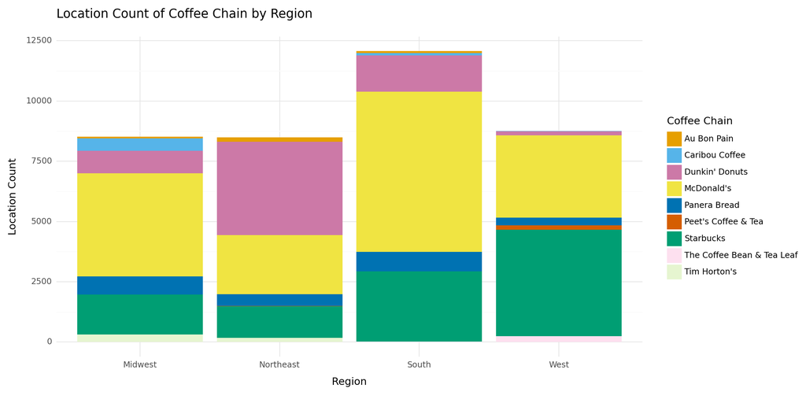

```
<Figure Size: (1200 x 600)>
```

```python
(ggplot(region_group, aes(
    x='Region',
    y='Location Count',
    fill='Coffee Chain'))
+ geom_bar(stat='identity', position='stack')
+ scale_fill_manual(values = ['#E69F00', '#56B4E9', '#CC79A7', '#F0E442', '#0072B2', '#D55E00', '#009E73', '#FDE0EF', '#E6F5D0'])
+ labs(title="Location Count of Coffee Chain by Region", x="Region", y="Location Count")
+ theme_minimal()
)
```

```python
state_group = merged_df.groupby(['State', 'Coffee Chain']).agg({'Location Count': 'sum'}).reset_index()
```

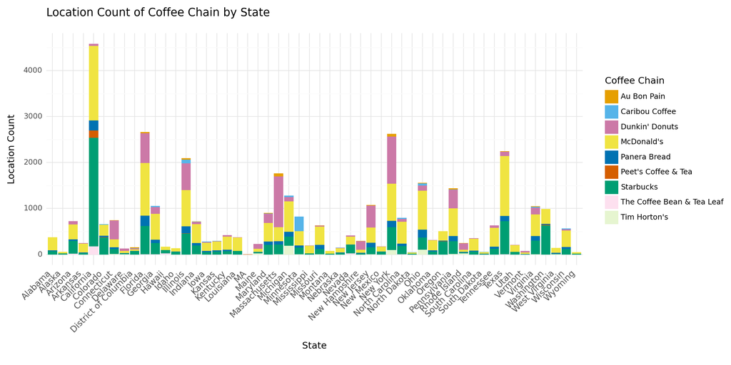

```
<Figure Size: (1200 x 600)>
```

```python
options.figure_size = (12, 6)
(ggplot(state_group, aes(
    x='State',
    y='Location Count',
    fill='Coffee Chain'))
+ geom_bar(stat='identity', position='stack')
+ scale_fill_manual(values = ['#E69F00', '#56B4E9', '#CC79A7', '#F0E442', '#0072B2', '#D55E00', '#009E73', '#FDE0EF', '#E6F5D0'])
+ labs(title="Location Count of Coffee Chain by State", x="State", y="Location Count")
+ theme_minimal()
+ theme(axis_text_x=element_text(rotation=45, hjust=1, size=10))
)
```

## Does the distribution of each chain’s stores match population distribution?

```python
pop_data_region = merged_df.groupby(['Region']).agg({'Location Count': 'sum', 'Population': 'sum'}).reset_index()

pop_data_region
```

|  | Region | Location Count | Population |
| --- | --- | --- | --- |
| 0 | Midwest | 8513 | 449933953 |
| 1 | Northeast | 8497 | 368996605 |
| 2 | South | 12067 | 740014870 |
| 3 | West | 8757 | 429178914 |

```python
#calculating the correlation coefficient between 'Location Count' and 'Population' by region
region_correlation_coefficient = pop_data_region['Location Count'].corr(pop_data_region['Population'])

region_correlation_coefficient
```

```
0.9805704959019388
```

```python
pop_data_state = merged_df.groupby(['State']).agg({'Location Count': 'sum', 'Population': 'sum'}).reset_index()

pop_data_state
```

|  | State | Location Count | Population |
| --- | --- | --- | --- |
| 0 | Alabama | 373 | 20097116 |
| 1 | Alaska | 57 | 1466782 |
| 2 | Arizona | 727 | 35757510 |
| 3 | Arkansas | 247 | 12046096 |
| 4 | California | 4585 | 237229338 |
| 5 | Colorado | 657 | 34642284 |
| 6 | Connecticut | 745 | 21635664 |
| 7 | Delaware | 133 | 4949740 |
| 8 | District of Columbia | 157 | 4137270 |
| 9 | Florida | 2663 | 129229122 |
| 10 | Georgia | 1059 | 74983356 |
| 11 | Hawaii | 170 | 7276355 |
| 12 | Idaho | 135 | 5517318 |
| 13 | Illinois | 2095 | 89687556 |
| 14 | Indiana | 717 | 47498696 |
| 15 | Iowa | 282 | 15951845 |
| 16 | Kansas | 297 | 14689400 |
| 17 | Kentucky | 420 | 27035016 |
| 18 | Louisiana | 373 | 18631028 |
| 19 | MA | 7 | 7029917 |
| 20 | Maine | 229 | 8174154 |
| 21 | Maryland | 902 | 37063344 |
| 22 | Massachusetts | 1764 | 42179502 |
| 23 | Michigan | 1284 | 70541317 |
| 24 | Minnesota | 827 | 39945458 |
| 25 | Mississippi | 195 | 11845116 |
| 26 | Missouri | 632 | 43084391 |
| 27 | Montana | 75 | 2168450 |
| 28 | Nebraska | 149 | 9807520 |
| 29 | Nevada | 414 | 21732298 |
| 30 | New Hampshire | 297 | 6887645 |
| 31 | New Jersey | 1076 | 55733964 |
| 32 | New Mexico | 174 | 8470088 |
| 33 | New York | 2621 | 121207494 |
| 34 | North Carolina | 798 | 62636328 |
| 35 | North Dakota | 53 | 3116376 |
| 36 | Ohio | 1556 | 82596136 |
| 37 | Oklahoma | 316 | 15837412 |
| 38 | Oregon | 510 | 25423536 |
| 39 | Pennsylvania | 1440 | 104021600 |
| 40 | Rhode Island | 249 | 6584274 |
| 41 | South Carolina | 355 | 20473700 |
| 42 | South Dakota | 56 | 3546668 |
| 43 | Tennessee | 632 | 27643360 |
| 44 | Texas | 2250 | 204018535 |
| 45 | Utah | 211 | 9814848 |
| 46 | Vermont | 76 | 2572308 |
| 47 | Virginia | 1048 | 60419751 |
| 48 | Washington | 992 | 38526405 |
| 49 | West Virginia | 146 | 8968580 |
| 50 | Wisconsin | 565 | 29468590 |
| 51 | Wyoming | 50 | 1153702 |

```python
#calculating the correlation coefficient between 'Location Count' and 'Population' by state
state_correlation_coefficient = pop_data_state['Location Count'].corr(pop_data_state['Population'])

state_correlation_coefficient
```

```
0.9419188342976466
```

The correlation coefficients for location count and population for region and state were very strong, with a .981 and .942 respectively. This would indicate a strong linear relationship between the number of locations of coffee shops in a given state and the population of that state. This logically makes sense, as the more people in a given state, the more potential consumers of coffee.

```python
correlations = merged_df.groupby('Coffee Chain').apply(lambda x: x['Location Count'].corr(x['Population']))

correlations
```

```
Coffee Chain
Au Bon Pain                   0.392680
Caribou Coffee                0.139496
Dunkin' Donuts                0.335717
McDonald's                    0.973994
Panera Bread                  0.843544
Peet's Coffee & Tea           0.760900
Starbucks                     0.880428
The Coffee Bean & Tea Leaf    0.637161
Tim Horton's                  0.495200
dtype: float64
```

## What is the relationship between number of locations and revenue for a coffee chain?

```python
locations_and_revenue = merged_df.groupby(['Coffee Chain']).agg({'Location Count': 'sum','Revenue': 'mean'}).reset_index()
```

```python
locations_and_revenue
```

|  | Coffee Chain | Location Count | Revenue |
| --- | --- | --- | --- |
| 0 | Au Bon Pain | 332 | 41.0 |
| 1 | Caribou Coffee | 623 | 262.0 |
| 2 | Dunkin' Donuts | 6481 | 1400.0 |
| 3 | McDonald's | 16781 | 23180.0 |
| 4 | Panera Bread | 2378 | 4800.0 |
| 5 | Peet's Coffee & Tea | 204 | 983.0 |
| 6 | Starbucks | 10294 | 26580.0 |
| 7 | The Coffee Bean & Tea Leaf | 248 | 500.0 |
| 8 | Tim Horton's | 500 | 2630.0 |

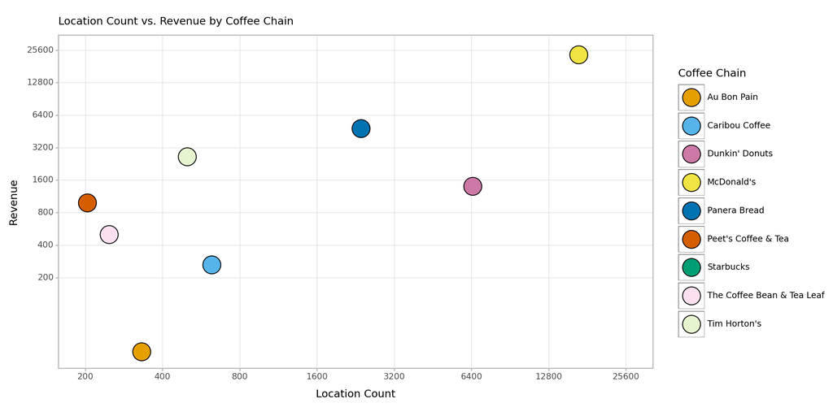

```
<Figure Size: (1200 x 600)>
```

```python
options.figure_size = (12, 6)
(ggplot(locations_and_revenue,
aes(
  x = "Location Count",
  y = "Revenue",
  fill = "Coffee Chain"
))
+ geom_point(size = 10)
+ scale_fill_manual(values = ['#E69F00', '#56B4E9', '#CC79A7', '#F0E442', '#0072B2', '#D55E00', '#009E73', '#FDE0EF', '#E6F5D0'])
+ scale_x_continuous(breaks = [200, 400, 800, 1600, 3200, 6400, 12800, 25600], labels = [200, 400, 800, 1600, 3200, 6400, 12800, 25600],  trans = "log2", limits = (200, 25600))
+ scale_y_continuous(breaks = [200, 400, 800, 1600, 3200, 6400, 12800, 25600], labels = [200, 400, 800, 1600, 3200, 6400, 12800, 25600], trans = "log2", limits = (40, 25600))
+ theme_light()
+ labs(x="Location Count", y="Revenue", fill="Coffee Chain", subtitle="Location Count vs. Revenue by Coffee Chain")
)
```

There is a positive relationship between the number of locations a coffee chain has and their revenue. This is being skewed by the fact that we are only analyzing US locations, while most of these companies have international locations which are included in their calculation of revenues. Therefore, there are many unaccounted for locations that would likely make the slope less steep if I fit a line through the data points.

## Do the financial data match what you’d expect based on the number and locations of the stores? What are some potential issues with the data?

In general, the financial data confirms the dominant players in the United States coffee market share. However, it is important to note that the data is being skewed by looking at a metric such as total revenue that includes revenue from stores outside of the US. This issue would also arise if we used stock price as our key metric, because that metric is also influenced from business dealings outside of the US.

# Automate

```python
def automate_locations(url):
    rows = []
    pattern = r'.*/([^/]+)$'
    match = re.search(pattern, url)
    name_url = match.group(1) if match else None
    split_name = name_url.split("-")[:-1]
    chain_name = " ".join(split_name).title()

    response = requests.get(url)
    soup = BeautifulSoup(response.content, "html.parser")
    results = soup.find_all("a", attrs={"class" : ""})
    state_pattern = fr"(.*)(?=\s+{chain_name} locations)"
    number_pattern= fr"(?<={chain_name} locations \()(\d+)"

    for result in results:
        state_match = re.search(state_pattern, result.text)
        number_match = re.search(number_pattern, result.text)
        if (state_match != None) & (number_match != None):
            state = state_match.group(0)
            number = int(number_match.group(1))

            rows.append({
            "State": state,
            "Location Count" : number,
            "Company Name" : chain_name
            })

        else:
            None

    return pd.DataFrame(rows)
```

```python
automate_locations("https://www.menuism.com/restaurant-locations/starbucks-coffee-39564")
```

```python
automate_locations("https://www.menuism.com/restaurant-locations/dunkin-donuts-181624")
```

Citations:

Daniel Hill had started the lab prior to the site going down so I worked with him on the initial webscraping code and automation. I gathered the actual site links from Eva Murdock.

Assisted by ChatGPT for: - manually reordering states in geom_bar plot - calculating correlation coefficient and applying across all chains - color selection

Sources:

- https://www.geeksforgeeks.org/formatted-string-literals-f-strings-python/
- https://www.statista.com/statistics/266466/net-revenue-of-the-starbucks-corporation-worldwide/#:~:text=Global%20revenue%20of%20Starbucks%202003%2D2022&text=Starbucks’%20net%20revenue%20reached%2026.58,previous%20year’s%20total%20of%2024.61.
- https://www.zippia.com/dunkin-donuts-careers-554008/revenue/
- https://www.zippia.com/peet-s-coffee-careers-34520/revenue/
- https://www.statista.com/statistics/291515/annual-revenues-tim-hortons-by-segment/#:~:text=Toronto%2Dbased%20quick%20service%20restaurant,compared%20to%20the%20previous%20year.
- https://www.panerabread.com/en-us/press/press-room/panera-brands-prepares-ipo-with-next-generation-leadership-and-board-appointments.html
- https://www.zippia.com/caribou-coffee-careers-18152/revenue/
- https://www.zippia.com/au-bon-pain-careers-513927/revenue/
- https://www.zippia.com/the-coffee-bean-tea-leaf-careers-27502/revenue/
- https://www.statista.com/statistics/208917/revenue-of-the-mcdonalds-corporation-since-2005/#:~:text=McDonald’s%20generated%20a%20total%20revenue%20of%2023.18%20billion%20U.S.%20dollars%20in%202022.